# Linked (D)GP Emulation

This vignette shows how to use the package to emulate a feed-forward system of three synthetic computer models.

## Load the package

```r
library(ggplot2)
library(patchwork)
library(dgpsi)
```

## Construct a synthetic system

We consider the following synthetic system

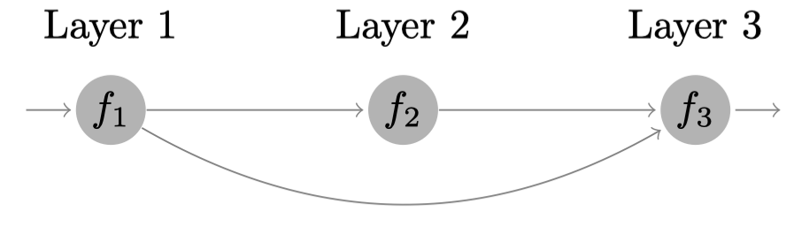

that involves three models defined by:

```r
# Model 1
f1 <- function(x) {
  (sin(7.5*x)+1)/2
}
# Model 2
f2 <- function(x) {
  2/3*sin(2*(2*x - 1))+4/3*exp(-30*(2*(2*x-1))^2)-1/3
}
# Model 3
f3 <- function(x) {
  x[1]*x[2]^2
}
# Linked Model
f123 <- function(x) {
  f3(c(f1(x),f2(f1(x))))
}
```

We then specify a seed with `set_seed()` from the package for reproducibility

```r
set_seed(999)
```

and generate 10 training data points for Model 1 and 15 training data points for Model 2 and 3:

```r
# Training data for Model 1
X1 <- seq(0, 1, length = 10)
Y1 <- sapply(X1, f1)
# Training data for Model 2
X2 <- seq(0, 1, length = 15)
Y2 <- sapply(X2, f2)
# Training data for Model 3
X3 <- cbind(X2, Y2)
Y3 <- apply(X3, f3, MARGIN = 1)
```

## Emulation of Model 1

We construct and train a GP emulator with Matérn-2.5 kernel:

```r
m1 <- gp(X1, Y1, name = "matern2.5")
```

```
## Auto-generating a GP structure ... done
## Initializing the GP emulator ... done
## Training the GP emulator ... done
```

We now validate the trained GP emulator by `plot()` by LOO (alternatively, one can first use `validate()` to store the LOO results before plotting with `plot()`):

```
## Initializing ... done
## Post-processing LOO results ... done
## Plotting ... done
```

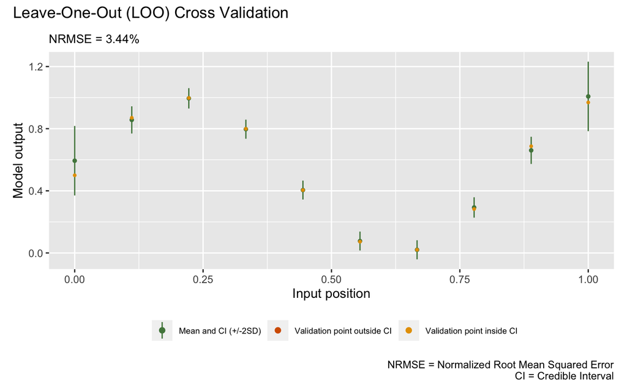

```r
plot(m1)
```

```r
m1 <- set_linked_idx(m1, c(1))
```

## Emulation of Model 2

We construct a two-layered DGP emulator with Matérn-2.5 kernels to emulate the Model 2:

```r
m2 <- dgp(X2, Y2, depth = 2, name = "matern2.5", linked_idx = c(1))
```

```
## Auto-generating a 2-layered DGP structure ... done
## Initializing the DGP emulator ... done
## Training the DGP emulator:
## Imputing ... done
```

Since all outputs of emulators in the first layer is from `m1` and `m2` uses the output from `m1` as its input, we set `linked_idx = c(1)` in `dgp()` above.

The following plot visualizes the LOO of the trained DGP emulator `m2`:

```
Initializing ... done
Post-processing LOO results ... done
Plotting ... done
```

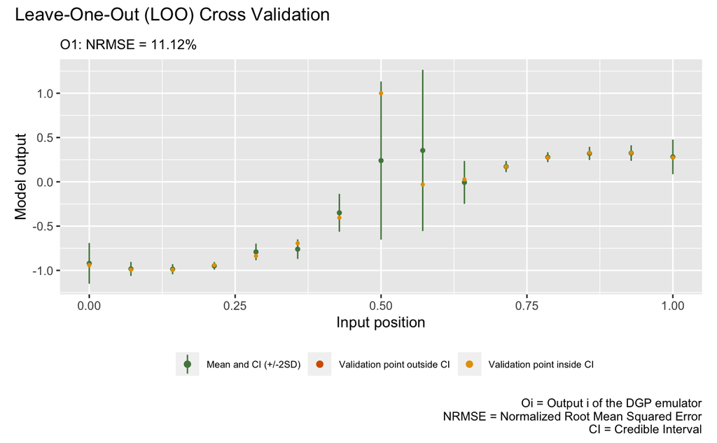

```r
plot(m2)
```

## Emulation of Model 3

We now construct a three-layered DGP emulator with Matérn-2.5 kernels to emulate the Model 3:

```r
m3 <- dgp( X3, Y3, depth = 3, name = "matern2.5", linked_idx = list( c(1), c(1) ) )
```

```
## Auto-generating a 3-layered DGP structure ... done
## Initializing the DGP emulator ... done
## Training the DGP emulator:
## Imputing ... done
```

Since `m3` takes both outputs from `m1` in layer 1 and `m2` in layer 2, we set `linked_idx = list( c(1), c(1) )`. The first vector in the list says that the output dimension 1 from all emulators (i.e., `m1`) in the first layer feeds into `m3` and the second vector in the list says that the output dimension 1 from all emulators (i.e., `m2`) in the second layer feeds into `m3`. Note that the dimensions in `X3` is ordered in consistent with `linked_idx`, i.e., the first and second columns of `X3` correspond to the output of `m1` and `m2` respectively.

The following plot visualizes the LOO of the trained DGP emulator `m3`:

```
Initializing ... done
Post-processing LOO results ... done
Plotting ... done
```

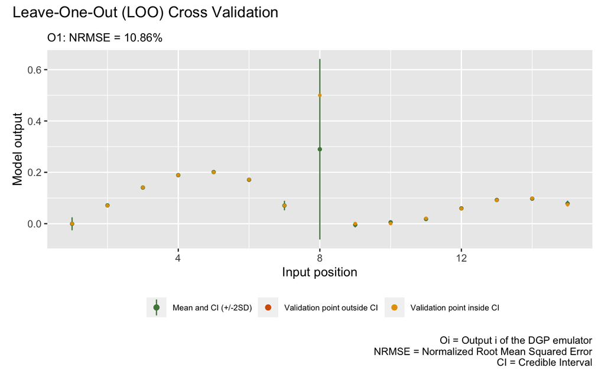

```r
plot(m3)
```

## Emulation of Linked Model

With the GP emulator `m1` (for Model 1), the DGP emulator `m2` (for Model 2), and the DGP emulator `m3` (for Model 3) at hand, we are now ready to build the linked emulator by first using `combine()` to construct the system hierarchy `struc` and then applying `lgp()` for the linked emulator.

```r
struc <- combine(list(m1), list(m2), list(m3))
m_link <- lgp(struc)
```

Note that each layer of an emulator system is represented by a list. In our case, each layer contains a single emulator. Therefore, we need to put the corresponding emulator in a list using `list()`.

We can check the relations between emulators in different layers by applying `summary()` to `m_link`:

```r
summary(m_link)
```

```
## +-----------+--------------+------+----------------------------+-----------------+
## | Layer No. | Emulator No. | Type |         Connection         | External Inputs |
## +-----------+--------------+------+----------------------------+-----------------+
## |  Layer 1  |    Emu 1     |  GP  |     Global input: [1]      |       No        |
## |  Layer 2  |    Emu 1     | DGP  | Emu 1 in Layer 1: output 1 |       No        |
## |  Layer 3  |    Emu 1     | DGP  | Emu 1 in Layer 1: output 1 |       No        |
## |           |              |      | Emu 1 in Layer 2: output 1 |                 |
## +-----------+--------------+------+----------------------------+-----------------+
## 1. 'Connection' gives the indices of emulators and the associated output dimensions that are linked to the emulator referred by 'Layer No.' and 'Emulator No.'.
## 2. 'External Inputs' indicates if the emulator (referred by 'Layer No.' and 'Emulator No.') has external inputs that are not provided by the feeding emulators.
```

```r
X_gp <- seq(0, 1, length = 15)
Y_gp <- sapply(X_gp, f123)
m_gp <- gp(X_gp, Y_gp, name = 'matern2.5')
```

```
## Auto-generating a GP structure ... done
## Initializing the GP emulator ... done
## Training the GP emulator ... done
```

Finally, we validate both the GP emulator and the linked emulator at 300 testing data points over $[0,1]$:

```r
# Testing input
test_x <- seq(0, 1, length = 300)
# Testing output
test_y <- sapply(test_x, f123)
# Validate GP emulator
m_gp <- validate(m_gp, x_test = test_x, y_test = test_y, verb = F)
# Validate linked emulator
m_link <- validate(m_link, x_test = test_x, y_test = test_y, verb = F)
```

and plot them to compare their emulation performances:

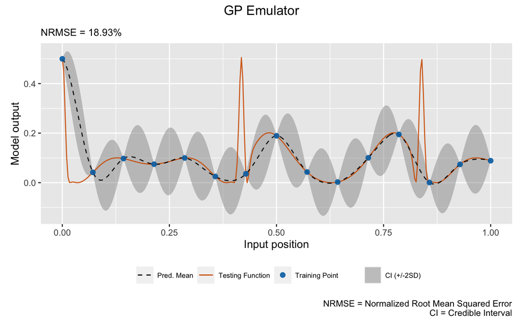

```r
# GP emulator
plot(m_gp, x_test = test_x, y_test = test_y, type = 'line', verb = F) +
  plot_annotation(title = 'GP Emulator', theme = theme(plot.title = element_text(hjust = 0.5)))
```

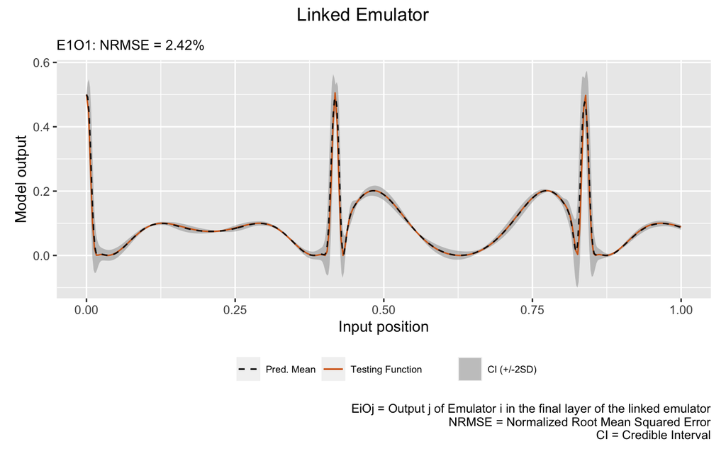

```r
# Linked emulator
plot(m_link, x_test = test_x, y_test = test_y, type = 'line', verb = F) +
  plot_annotation(title = 'Linked Emulator', theme = theme(plot.title = element_text(hjust = 0.5)))
```

It can be seen from the above plots that the linked emulator outperforms the GP emulator with significantly better mean predictions and predictive uncertainties.

In real-life applications, we are rarely able to generate this many testing data points from the underlying computer simulators to evaluate the emulators over the whole input space. However, we are still able to retain some available realizations from the computer simulators for the linked emulator validation. Say we were able to afford 20 runs of the above linked computer system:

```r
# OOS testing input
test_x_oos <- sample(seq(0, 1, length = 300), 20)
# OOS testing output
test_y_oos <- sapply(test_x_oos, f123)
```

Then, we can conduct OOS validations for the GP emulator:

```
## Initializing ... done
## Post-processing OOS results ... done
## Plotting ... done
```

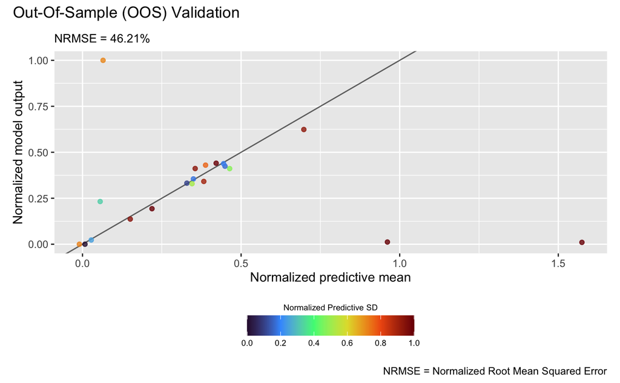

```r
plot(m_gp, test_x_oos, test_y_oos, style = 2)
```

and the linked emulator:

```
## Initializing ... done
## Post-processing OOS results ... done
## Plotting ... done
```

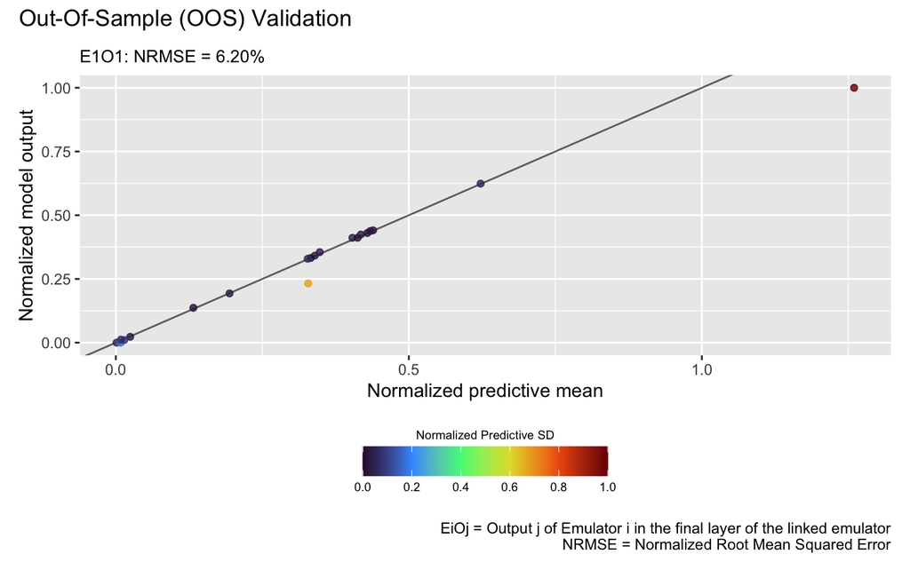

```r
plot(m_link, test_x_oos, test_y_oos, style = 2)
```

which show that the linked emulator outperforms the GP emulator with significantly better predictive accuracy and lower NRMSE.